# Data Science Capstone Project Milestone Report

Akhil kumar

Tuesday, March 24, 2015

## Task 0: Understanding the Problem

The reason for this report is to investigate the corpus data provided by the Coursera Data Science Capstone Course and use it to create a text predicting model. The model should predict the most probable word by using an input string.

Below are few things to be noted from the given corpus data. * The data contains a lot unnecessary noise and other foreign words and words from different encodings. * Most of the words repeat only few times, so associating each words with other is important to predict the next word. * We select only english language words by using a regular expression.

## Task 1: Data Acquisition & Cleaning.

Make sure the path for working directory is set to location where your files are stored. The data provided by Coursera in partnership with Swiftkey contains data for different languages like Russian, German, Finnish & english. We are intrested in english so lets load the files inside the “en_US” folder.

### Import Datasets.

```r
news <- readLines("C:/DS Capstone/final/en_US/en_US.news.txt", encoding = "UTF-8")
twitter <- readLines("C:/DS Capstone/final/en_US/en_US.twitter.txt", encoding = "UTF-8")
blogs <- readLines("C:/DS Capstone/final/en_US/en_US.blogs.txt", encoding = "UTF-8")
```

Here’s the basic inforamtion about the three files.

```
##                    Blogs  Twitter     News
## Number of Lines  1010242  2360148   899288
## Number of words 34762304 30092866 37541795
```

### Sampling

These files are huge, so lets subset the data and select a portion of data using sampling so that our subset is a representative sample. For simplicity, I’m conisdering only 10% of the data from each file.

```r
set.seed(48)
news.sample <- sample(news, length(news)*0.10, replace = FALSE)
twitter.sample <- sample(twitter, length(twitter)*0.10, replace = FALSE)
blogs.sample <- sample(blogs, length(blogs)*0.10, replace = FALSE)
```

Here’s the brief summary of the sample we just made from the main data.

[output not shown]

Lets plot the histogram of number of words in each lines for the 3 sampled data.

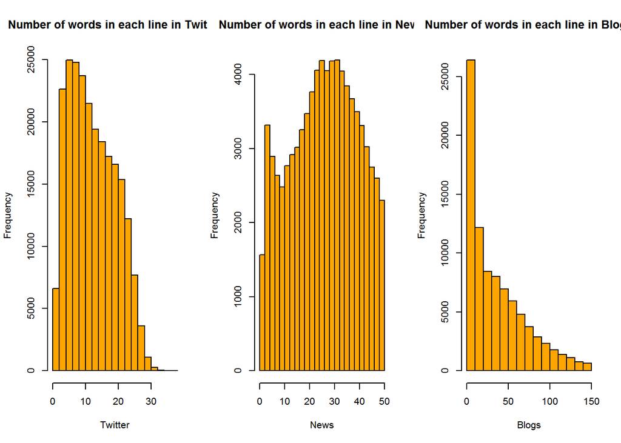

### Data Cleaning.

Lets combine all the 3 data files into a single file. First we need to remove the numbers, then any special characters, then we remove all the extra white space and replace them with a single space.

```r
library(tm)
library(SnowballC)
new.data <- c(news.sample,twitter.sample,blogs.sample)
corpus <- Corpus(VectorSource(new.data))
remove.decimals <- function(x) {gsub("([0-9]*)\\.([0-9]+)", "\\1 \\2", x)}
remove.hashtags <- function(x) { gsub("#[a-zA-z0-9]+", " ", x)}
remove.noneng <- function(x) {gsub("\\W+", " ",x)}
corpus <- tm_map(corpus, remove.decimals)
corpus <- tm_map(corpus, removeNumbers)
corpus <- tm_map(corpus, remove.noneng)
corpus <- tm_map(corpus, remove.hashtags)
corpus <- tm_map(corpus, stripWhitespace)
corpus <- tm_map(corpus, removePunctuation)
corpus <- tm_map(corpus, tolower)
corpus <- tm_map(corpus, removeWords, stopwords("english"))
```

There a lot of words which are rude and bad which are called profanity words. We need to find such words and stop predicting them. I found a dataset which has almost 723 such words. We will use those words as stopwords.

```r
profanity <- read.csv("C:/DS Capstone/final/en_US/Terms-to-block.csv", header = F)
profanity <- rep(profanity$V1)
corpus <- tm_map(corpus, removeWords, profanity)
```

## Task 2: Exploratory Analysis.

### Tokenization

Lets create One-Gram Tokenization.

```r
options( java.parameters = "-Xmx4g" )
library(rJava)
library(RWeka)
options(mc.cores = 1)
one.g_Tokenizer <- NGramTokenizer(corpus, Weka_control(min = 1, max = 1))
one.g <- data.frame(table(one.g_Tokenizer))
one.g.sorted <- one.g[order(one.g$Freq,decreasing = TRUE),]
```

Here are the top 20 one grams.

```r
one.g.sorted[1:20,]
```

```
##       one.g_Tokenizer Freq
## 10678            said  302
## 8613              one  275
## 13575            will  254
## 6720             just  226
## 7198             like  207
## 1915              can  197
## 12513            time  175
## 9053           people  160
## 545              also  156
## 8310              new  143
## 6877             know  142
## 5235              get  140
## 3249              day  137
## 1066             back  135
## 8459              now  132
## 13085              us  130
## 5347             good  124
## 4745            first  113
## 6136               im  113
## 8110             much  113
```

Lets create Two-Gram Tokenization.

```r
two.g_Tokenizer <- NGramTokenizer(new.data, Weka_control(min = 2, max = 2))
two.g <- data.frame(table(two.g_Tokenizer))
two.g.sorted <- two.g[order(two.g$Freq,decreasing = TRUE),]
```

Here are the top 20 Two-grams

```r
two.g.sorted[1:20,]
```

[output not shown]

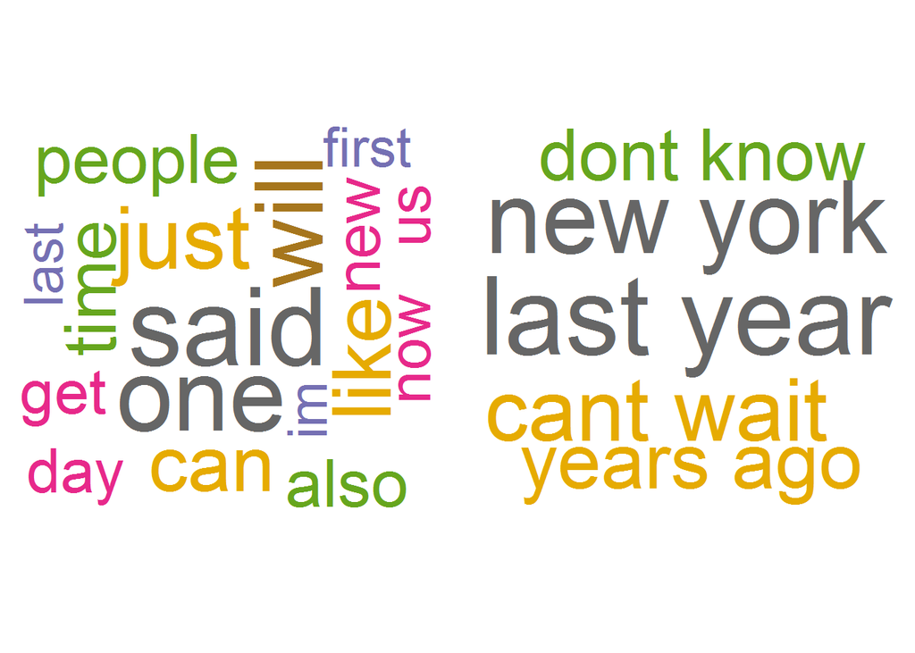

```r
par(mfrow = c(1,2))
library(wordcloud)
wordcloud(one.g.sorted[,1],freq=one.g.sorted[,2],scale=c(5,1),random.order=F,rot.per=0.5,min.freq=100,colors=brewer.pal(8,"Dark2"))
wordcloud(two.g.sorted[,1],freq=one.g.sorted[,2],scale=c(5,1),random.order=F,rot.per=0.5,min.freq=100,colors=brewer.pal(8,"Dark2"))
```